# Is Going Vegetarian Worth It?

[figure not shown]

[figure not shown]

[figure not shown]

[figure not shown]

[figure not shown]

[figure not shown]

[figure not shown]

[figure not shown]

[figure not shown]

[figure not shown]

[figure not shown]

[figure not shown]

[2 more figures not shown]

# Introduction

**Is Going Vegetarian Worth It?**

**The hidden environmental impacts behind what we eat.**

It is hard to escape the problems our world faces. You don’t have to look far to see how our actions are cutting deep into the natural processes of our planet. Even when we aren’t searching for it, our teachers, peers, and the news remind us how the world is hurting and how we are part of the problem. Our generation has come of age alongside climate change. Perhaps this reflects present bias; however, as young adults, we are directly experiencing and feeling the detrimental effects of climate change as they become increasingly visible, recognized, and understood. “Global warming,” “sea level rise,” “carbon emissions,” “greenhouse effect,” “fossil fuels,” “pollution”—the list goes on—have been familiar words since grade school. Since we could talk, we have been spoon-fed solutions: turn the water off when you brush your teeth, “keep calm and don’t litter.” We recycle and turn out the lights, yet we still watch the world crumble before our eyes. The prolonged and consistent saturation of information we receive can make us apathetic, indifferent, detached, and unconcerned, even while we call ourselves environmentalists.

As a 20-something “environmentalist” in college, I have often felt limited in how I can best serve the environment; while I try to live sustainably, I feel hindered in what I can *actually* do to combat climate change. Amidst today’s climate crisis, most of our actions to combat climate change focus on the transition to clean energy and reducing our reliance on fossil fuels. I try to limit my carbon footprint by minimizing driving and flying, but with short school breaks and my family living across the country, I find myself prioritizing my family over my carbon emissions. I turn out the lights when I can and try to minimize my energy use, but I have little control over Sewanee’s transition to clean energy. I even live in the Greenhouse, a sustainable-themed living community, but our house is poorly insulated and drafty, an energy suck. In this stage of life, I am often unable to choose the sustainable path. While these conventional pursuits are vital, they are often inapplicable to my life right now. But perhaps there is a different way we can combat climate change right under our noses (literally).

We often underrate another possible area that could minimize our impact on the climate– **the way we eat**. This project will explore how what we eat impacts the environment and how small changes in our diet could help combat climate change.

**Effects of Agriculture on the Climate**

Agriculture is a huge contributor to greenhouse gases and climate change; thus, the food we eat has huge impacts on the environment. To fully understand how our diet can impact the climate, we first need to look at **how agriculture as a whole drives climate change**. These three data sets compare agriculture emissions to other sectors that we more commonly associate with climate change, such as electricity and transportation; while we are all familiar with how driving our car releases CO2 into the atmosphere, this data shows how we should be just as concerned about how the sandwich we had for lunch also contributes to greenhouse gases in the atmosphere.

**These three graphs show how agriculture greatly contributes to greenhouse gases and thus, climate change.**

### Greenhouse Gass Emissions by Sector

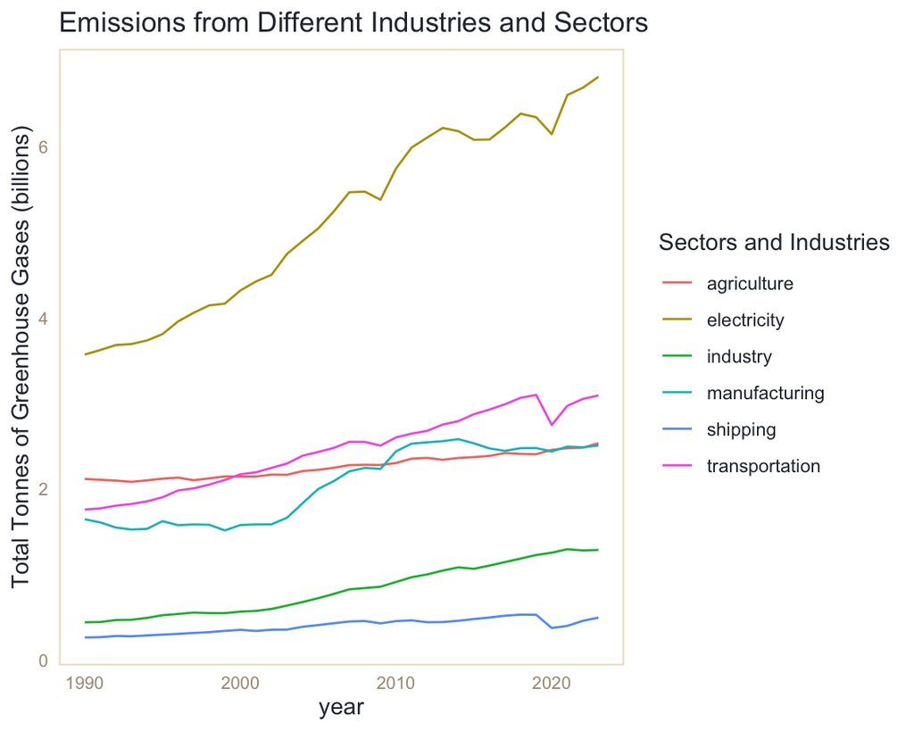

### Methane Emissions by Sector

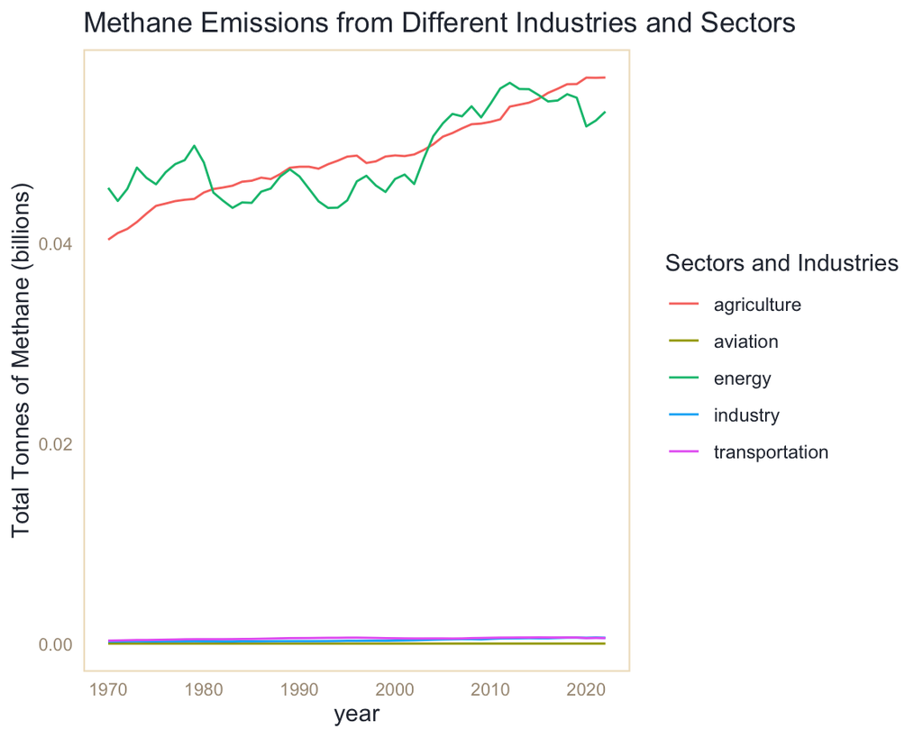

This graph shows how methane emissions due to agriculture are actually higher than most other sectors that we commonly associate with climate change, and on par with emissions from energy consumption.

### Ammonia Emissions by Sector

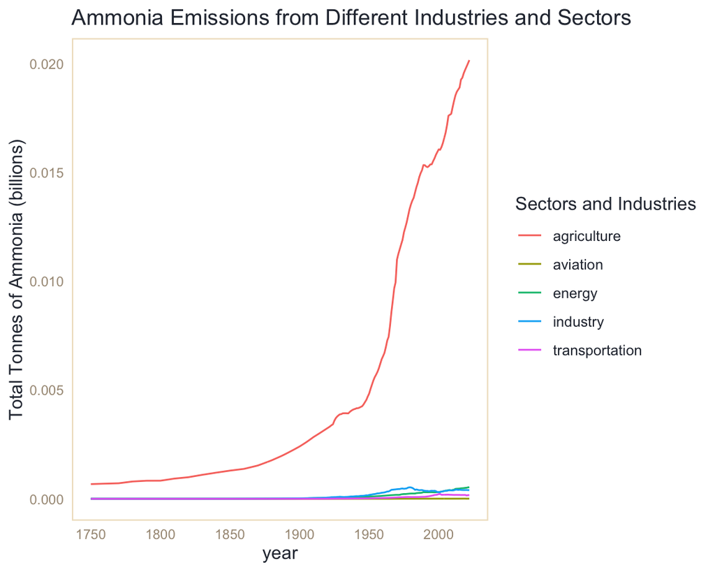

This graph shows how Ammonia emissions due to agriculture are **much** higher than most other sectors that we commonly associate with climate change!

# Our Plates

**What Do We Eat?**

**What food are we actually consuming and how does it impact the environment?**

It is clear that agriculture and food production heavily impact our environment. But what aspects of our diet are most detrimental? First, we need to determine what **our diet consists of**. In the United States, our daily caloric intake is dominated by oils and fats. Cereals and grains come next, followed by sugar and meat. This is an *average* American diet. I encourage you to think about your own diet. When you make up a plate of food at McClurg or order at a restaurant, what makes up the food on your plate? How do you think your diet compares to the average American diet? By recognizing what we fuel our bodies with, we can begin to understand how what we eat impacts the environment.

### What We Eat in the US: where we get our energy

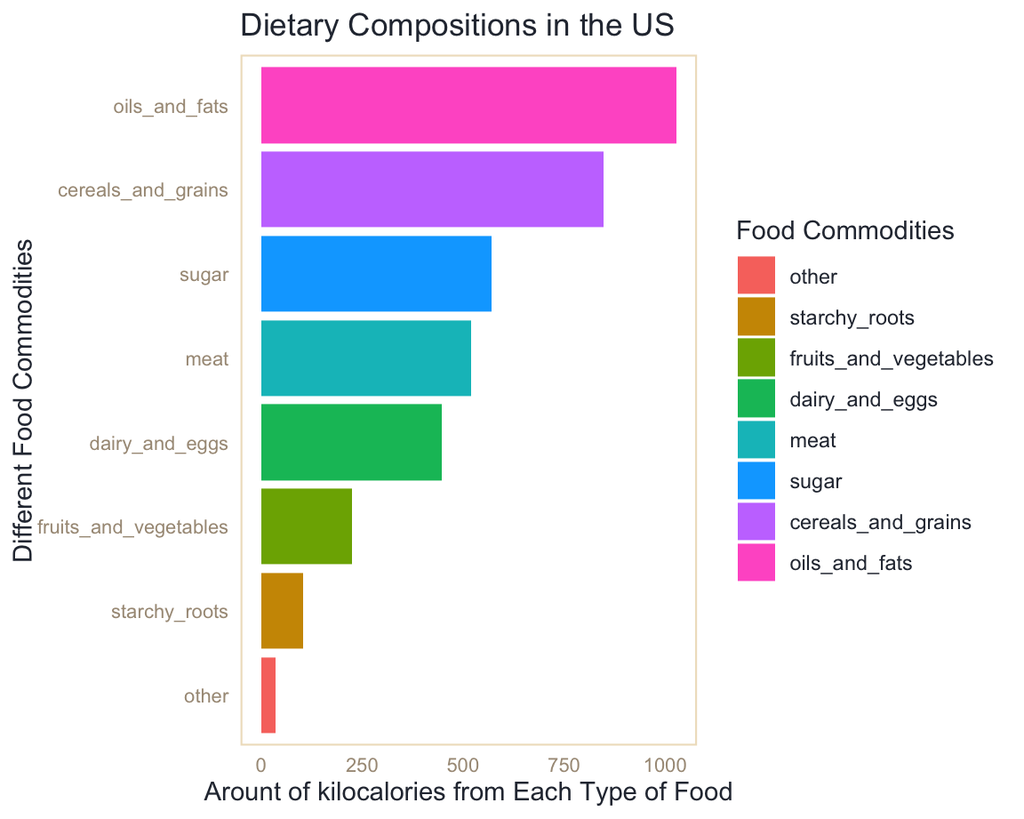

### Impacts on the Environment

**How our food impacts the environment.**

Now that we know what we eat, which aspects of our diet have the greatest impact on the environment? These four graphs examine how different types of food affect the environment through **carbon emissions and land use**. The graphs show carbon emissions and land usage for a kilogram of a given food product. For example, how much land is needed to produce 1 kilogram of meat versus 1 kilogram of vegetables? How do the carbon emissions of 1 kilogram of oatmeal compare to 1 kilogram of scrambled eggs? With these graphs, we can begin to compare how different foods impact the environment.

Carbon emissions from the food we consume contribute directly to global warming and climate change. When natural land is converted to agricultural land to meet food demand, it reduces biodiversity, decreases the amount of habitable land for different species, increases edge effects, and has an overall negative impact on our environment. Different types of food require different amounts of land and emit different amounts of co2.

### Impacts of what we eat: Carbon Emissions

```
# A tibble: 6 × 3
  entity             year ghg_emissions_per_kilogram__poore__and__nemecek__2018
  <chr>             <dbl>                                                 <dbl>
1 Apples             2010                                                  0.43
2 Bananas            2010                                                  0.86
3 Barley             2010                                                  1.18
4 Beef (beef herd)   2010                                                 99.5
5 Beef (dairy herd)  2010                                                 33.3
6 Beet Sugar         2010                                                  1.81
```

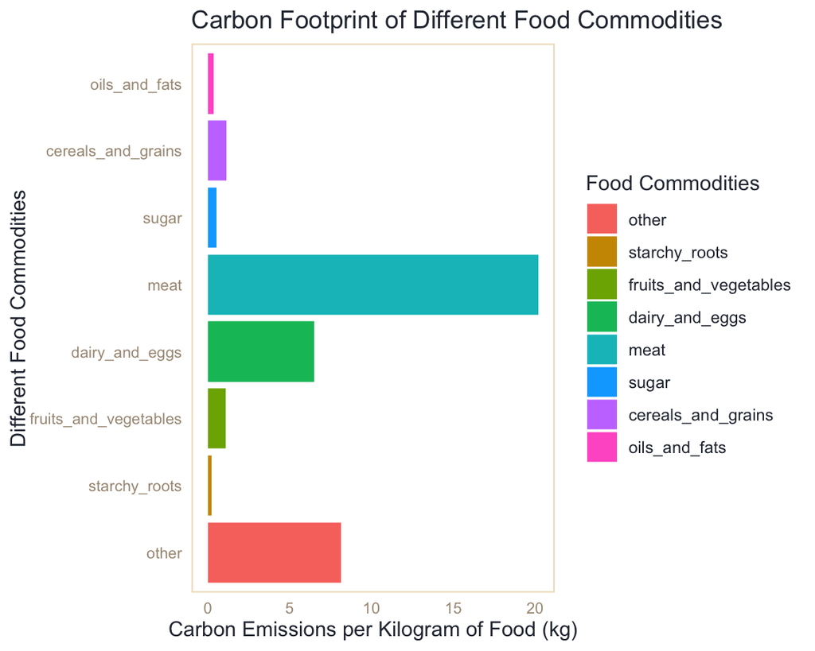

### Carbon Emissions for Specific Foods

[interactive chart not shown]

### Impacts of what we eat: Land Use

```
# A tibble: 6 × 3
  entity             year land_use_per_kilogram__poore__and__nemecek__2018
  <chr>             <dbl>                                            <dbl>
1 Apples             2010                                             0.63
2 Bananas            2010                                             1.93
3 Barley             2010                                             1.11
4 Beef (beef herd)   2010                                           326.
5 Beef (dairy herd)  2010                                            43.2
6 Beet Sugar         2010                                             1.83
```

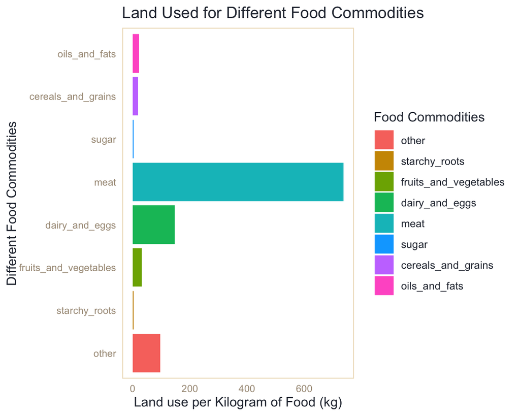

### Land Use for Specific Foods

[interactive chart not shown]

# Our Meat Consumption

**How Much Meat do we Eat in the US?**

**How our meat consumption compares to other countries and the country’s past.**

While meat doesn’t account for the majority of our calories here in the US, we consume significantly more meat compared to other countries around the world. The United States is one of the leading meat-consuming countries per capita. **People eat more meat here daily than almost anywhere else in the world**. The US’s meat consumption is *over two times greater* than the world’s average meat consumption, and only two countries (Mongolia and Tonga, two very small countries comparatively) consume more meat than the United States. Meat consumption is generally greater in high-income countries, yet even among similar socioeconomic countries, the US consumes more meat.

Meat consumption has drastically skyrocketed since the 1960s; we consume much more meat today than throughout most of history. Within our diet, we have been increasingly reliant on meat.

With these drastic numbers, it is clear that we are eating more meat than the rest of the world and even our past selves. Within the United States, there is ample room to eat less meat and cater our diets to be less meat-centric without giving up meat completely. While going vegetarian could be a beneficial action for the environment, due to our current staggering consumption of meat, even reducing our consumption to be comparable to that of other countries or our historic rates would significantly reduce our carbon footprint and land use.

### US Meat Consumption Compared to Other Countries

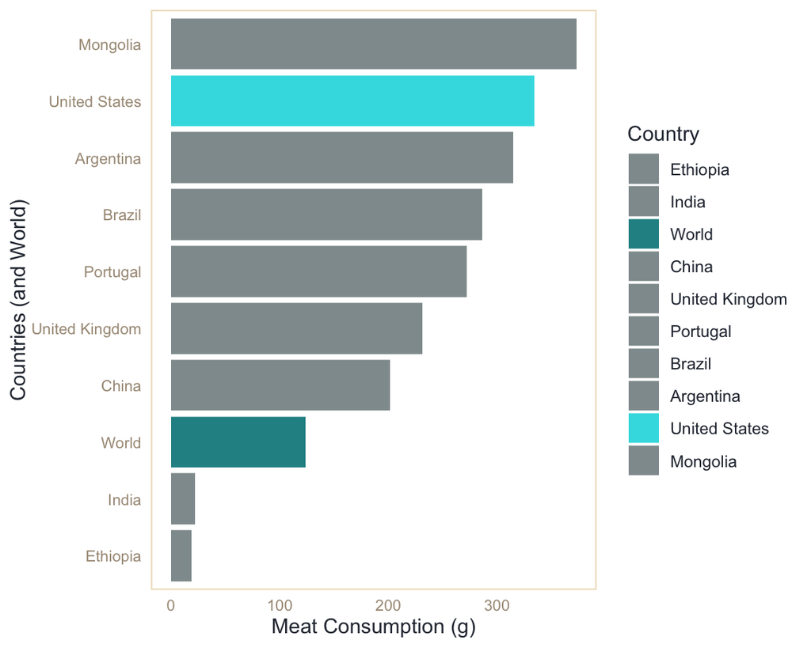

### US Daily Meat Consumption Throughout History

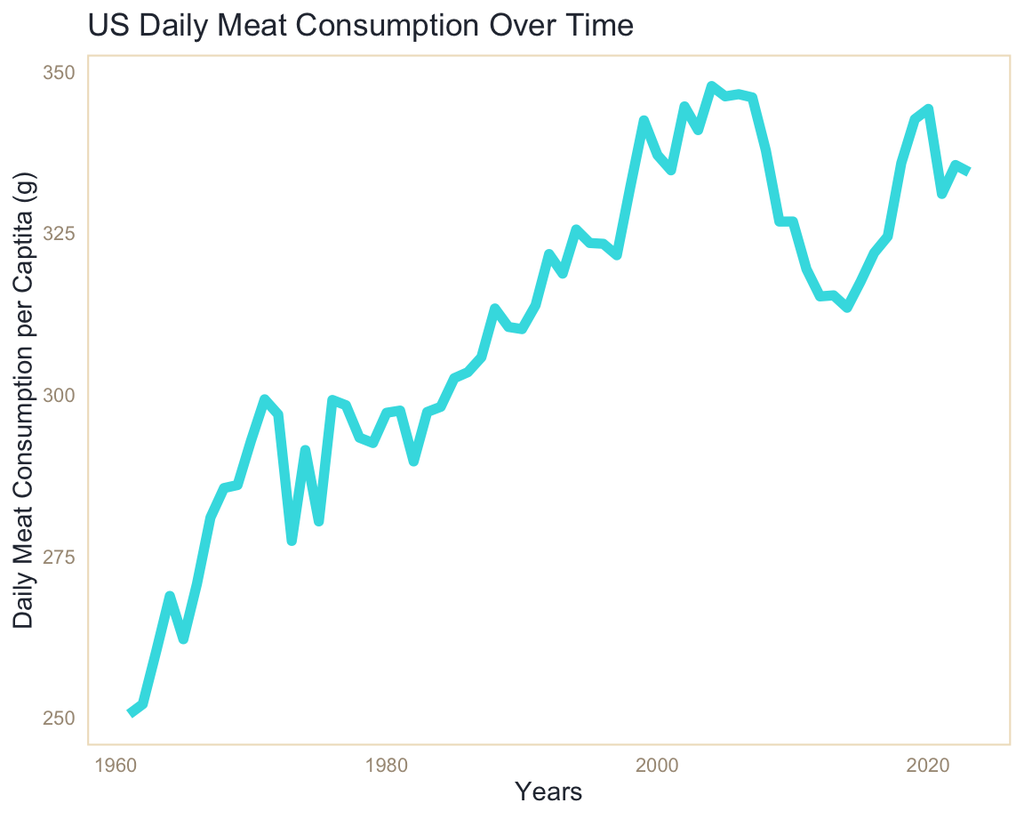

# Environmental Impacts of the Meat We Eat

**Comparing Diets**

**How a vegetarian diet compares to a meat eating diet.**

Many people eat meat for its protein. While protein is obviously very important, it is also important to recognize how different sources of protein impact the environment. These graphs show the carbon footprint of different meats and meat substitutes for 100 grams of protein. In these graphs, we can clearly see the environmental impacts of beef specifically.

**Now imagine**

100 grams of protein is about 5 hamburgers. Imagine eating 5 hamburgers over the course of a week. Likely, this would not account for *all* of your protein intake, but it would likely be five clear moments when you could decide to make a change and either eat a hamburger, or try something else. Let’s imagine three different scenarios.

Toggle between the tabs on the right to see how swapping the beef for chicken and going vegetarian would change the carbon footprint of your week’s protein intake.

```
# A tibble: 6 × 3
  entity            year ghg_emissions_per_100g_protein__poore__and__nemecek__…¹
  <fct>            <dbl>                                                   <dbl>
1 Beef (beef herd)  2010                                                  49.9
2 Lamb & Mutton     2010                                                  19.9
3 Other Pulses      2010                                                   0.836
4 Pig Meat          2010                                                   7.61
5 Poultry Meat      2010                                                   5.70
6 Tofu              2010                                                   1.98
# ℹ abbreviated name:
#   ¹ghg_emissions_per_100g_protein__poore__and__nemecek__2018
```

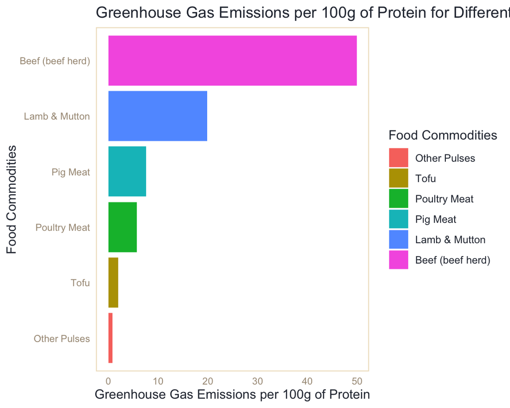

### Swap Meat Type

Now, imagine eating five chicken sandwiches instead of five hamburgers. You can see how this change dramatically changes your carbon footprint.

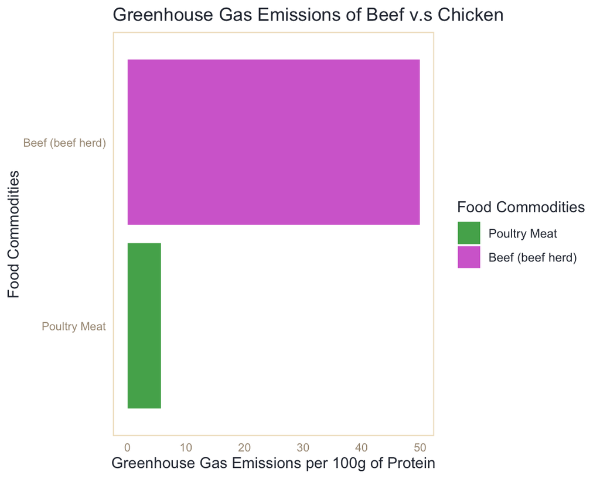

### vegetarian

Now, imagine eating tofu instead of five hamburgers. You can see how this change dramatically changes your carbon footprint.

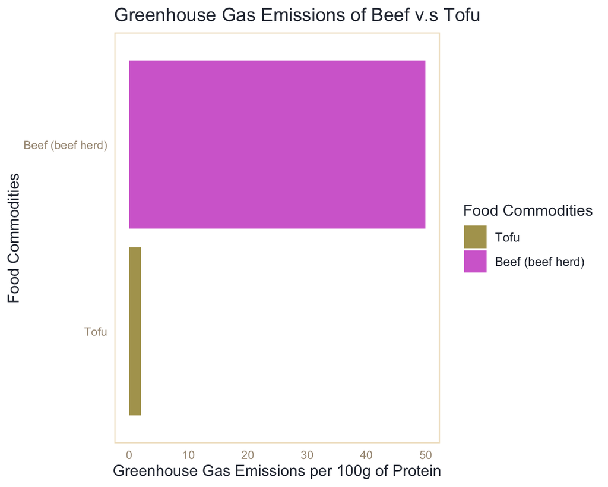

### vegetarian

Now, imagine eating beans instead of five hamburgers. You can see how this change dramatically changes your carbon footprint.

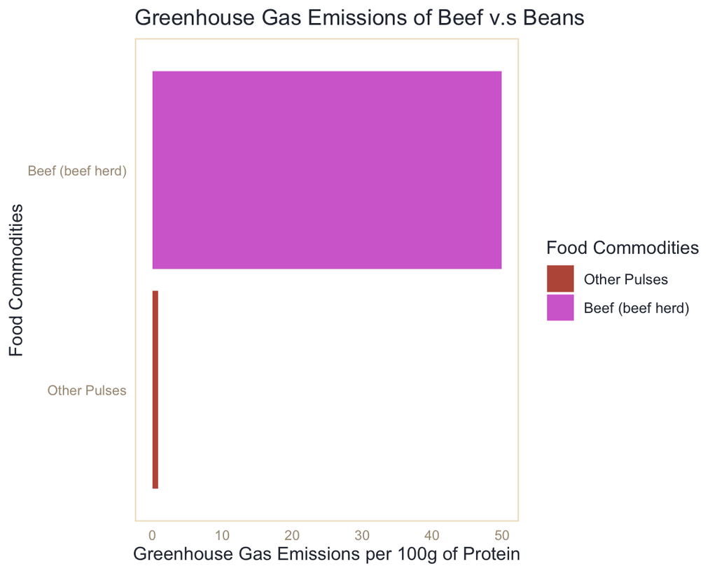

# Consulsion

**So… Is It Worth It?**

**How to think moving forward.**

As we have seen, agriculture and the production of food have significant implications for our environment. Intentional food consumption can alter our impacts on the environment and become climate activism!

Agriculture is a major driver of climate change, but meat production has particular detrimental effects on the environment. Meat production emits large amounts of CO2 and other greenhouse gases into the atmosphere. Meat production, particularly beef production, emits far more greenhouse gases than other types of food. By reducing meat consumption worldwide, the amount of greenhouse gases being emitted will also decrease. In this way, eating less meat is a form of climate action.

Beyond producing large amounts of greenhouse gases, meat (once again, particularly beef) production requires a large amount of land in comparison to other foods. This is land that could be or once was forested. Land that is turned into agricultural land is stripped of its natural biodiversity and functions. This is detrimental to our land across the globe. By decreasing our reliance on meat, less land is needed for agricultural purposes, which thus helps support our land.

In the US, particularly, our diet directly degrades the environment. The US consumes more meat than almost every other country. Maybe unsurprisingly at this point, the US is also one of the top emitting countries of greenhouse gases. Because most of us center much of our diet around meat, there is ample room for improvement, and our actions can lead to significant change. Through conscious eating, we can reduce our carbon and land footprints by limiting our meat consumption, particularly beef!

The data shows that we don’t need to eliminate all meat to have meaningful impacts on our footprints, but make intentional shifts in the **amount** and **type** of meat we are consuming. Our meat choices can decrease our carbon and land use significantly!

**Sustainable Development Goals.**

Food is intertwined deeply within us, our society, and our planet; The food we eat relates to multiple Sustainable Development Goals. In this project, we will primarily focus on how changing what we eat relates to:

**Goal 13: Climate action** and **Goal 15: Life on Land**